# Lecture 2 Exercises

## Short Questions

1. How do you check whether an element is part of a list?
2. How do you reference a global variable in `.query()`?

```python
# Write your answers here as comments:

#1 How I know that an element is a part of list.
colors = ["red", "green", "yellow"]
"red" in colors

#2
import pandas as pd
carfeatures = pd.read_csv("data_raw/features.csv")
category = 8

#@category → look for the Python variable named category
df = carfeatures.query("cylinders == @category")
print(df)
```

```
      mpg  cylinders  displacement horsepower  weight  acceleration vehicle_id
0    18.0          8           307        130    3504          12.0  C-1689780
1    15.0          8           350        165    3693          11.5  B-1689791
2    18.0          8           318        150    3436          11.0  P-1689802
3    16.0          8           304        150    3433          12.0  A-1689813
4    17.0          8           302        140    3449          10.5  F-1689824
..    ...        ...           ...        ...     ...           ...        ...
291  19.2          8           267        125    3605          15.0  C-1692981
292  18.5          8           360        150    3940          13.0  C-1692992
298  23.0          8           350        125    3900          17.4  C-1693058
300  23.9          8           260         90    3420          22.2  O-1693080
364  26.6          8           350        105    3725          19.0  O-1693784

[103 rows x 7 columns]
```

## Long Questions

Import the pandas and matplotlib packages

```python
# Write your own code
# already imported panda

import matplotlib.pyplot as plt
```

(a) Checking a string condition

- Define a variable "fruit" with the value "apple"
- Define a list

list_fruits = ["banana","orange","apple"]

- Write an expression to test whether "fruit" is contained in "list_fruits"

Hint: Use the "in" command. The final output should be True/False.

To get full points run all of the above commands

```python
# Write your own code


fruit = "straberry"
list_fruits = ["banana", "orange", "apple"]
fruit in list_fruits
# Here, fruit is the element we are looking for, while list_fruits is the list we are searching.
# If assigned fruit is present in list we should see "True" Or "False"
```

```
False
```

(b) Classifying a variable

- Define a new variable "year" an assign the value "2008"
- Write an if/else statement that does the following
  - print("Year 2000 or earlier") if the year is less than or equal to 2000.
  - print("Between 2001 and 2005") if the year is between 2001 and 2005.
  - print("Year 2006 or later") if the year is after 2005.

To get full points you must do all of the above instructions

```python
# Write your own code
year = 2008
if year <= 2000:
    print("Year 2000 or earlier")
elif year <= 2005:
    print("Between 2001 and 2005")
else:
    print("Year 2006 or later")
```

```
Year 2006 or later
```

(c) Split a dataset into subsets

```
    np.random.choice(list_status,
                     size = n,
                     p = list_prob)
```

$\qquad$ to create a new column called "status"  
$\qquad$ which randomly assigns each row to "0" or "1"  
$\qquad$ with equal probability

- Use .query() to subset all observations with status == 0.  
  store it in a new dataset called "data0"
- Use .query() to subset all observations with status == 1.  
  store it in a new dataset called "data1"

```python
# Write your own code

import numpy as np

# Import the dataset
data = pd.read_csv("data_raw/features.csv")
print(data.head())

# Create the lists
list_status = [0, 1]
list_prob = [0.5, 0.5]
print(list_status)
print(list_prob)

# Number of rows in the dataset
n = len(data)
print(n)

# Create a new column called status
data["status"] = np.random.choice(
    list_status,
    size=n,
    p=list_prob
)
print(data.head())

# Create data0 containing status 0
data0 = data.query("status == 0")
print(data0.head())

# Create data1 containing status 1
data1 = data.query("status == 1")
print(data1.head())
```

```
    mpg  cylinders  displacement horsepower  weight  acceleration vehicle_id
0  18.0          8           307        130    3504          12.0  C-1689780
1  15.0          8           350        165    3693          11.5  B-1689791
2  18.0          8           318        150    3436          11.0  P-1689802
3  16.0          8           304        150    3433          12.0  A-1689813
4  17.0          8           302        140    3449          10.5  F-1689824
[0, 1]
[0.5, 0.5]
398
    mpg  cylinders  displacement horsepower  weight  acceleration vehicle_id  \
0  18.0          8           307        130    3504          12.0  C-1689780
1  15.0          8           350        165    3693          11.5  B-1689791
2  18.0          8           318        150    3436          11.0  P-1689802
3  16.0          8           304        150    3433          12.0  A-1689813
4  17.0          8           302        140    3449          10.5  F-1689824
```

[output cut: 33 more lines]

For questions (d) through (f) mport the dataset  
"data_raw/fifa23_players_basic.csv"

- It's a dataset on professional soccer players
- Rows correspond to players (18,539)
- Columns contain attributes of players (32)
- Try to view the dataset before starting

```python
# Write your own code

import pandas as pd

# Import the FIFA dataset
fifa = pd.read_csv("data_raw/fifa23_players_basic.csv")

# View the dataset
display(fifa)

fifa.shape

fifa.columns
```

|  | Known As | Full Name | Overall | Potential | Value(in Euro) | Positions Played | Best Position | Nationality | Image Link | Age | ... | Preferred Foot | Weak Foot Rating | Skill Moves | International Reputation | National Team Name | National Team Image Link | National Team Position | National Team Jersey Number | Attacking Work Rate | Defensive Work Rate |
| --- | --- | --- | --- | --- | --- | --- | --- | --- | --- | --- | --- | --- | --- | --- | --- | --- | --- | --- | --- | --- | --- |
| 0 | L. Messi | Lionel Messi | 91 | 91 | 54000000 | RW | CAM | Argentina | https://cdn.sofifa.net/players/158/023/23_60.png | 35 | ... | Left | 4 | 4 | 5 | Argentina | https://cdn.sofifa.net/flags/ar.png | RW | 10 | Low | Low |
| 1 | K. Benzema | Karim Benzema | 91 | 91 | 64000000 | CF,ST | CF | France | https://cdn.sofifa.net/players/165/153/23_60.png | 34 | ... | Right | 4 | 4 | 4 | France | https://cdn.sofifa.net/flags/fr.png | ST | 19 | Medium | Medium |
| 2 | R. Lewandowski | Robert Lewandowski | 91 | 91 | 84000000 | ST | ST | Poland | https://cdn.sofifa.net/players/188/545/23_60.png | 33 | ... | Right | 4 | 4 | 5 | Poland | https://cdn.sofifa.net/flags/pl.png | ST | 9 | High | Medium |
| 3 | K. De Bruyne | Kevin De Bruyne | 91 | 91 | 107500000 | CM,CAM | CM | Belgium | https://cdn.sofifa.net/players/192/985/23_60.png | 31 | ... | Right | 5 | 4 | 4 | Belgium | https://cdn.sofifa.net/flags/be.png | RF | 7 | High | High |
| 4 | K. Mbappé | Kylian Mbappé | 91 | 95 | 190500000 | ST,LW | ST | France | https://cdn.sofifa.net/players/231/747/23_60.png | 23 | ... | Right | 4 | 5 | 4 | France | https://cdn.sofifa.net/flags/fr.png | ST | 10 | High | Low |
| ... | ... | ... | ... | ... | ... | ... | ... | ... | ... | ... | ... | ... | ... | ... | ... | ... | ... | ... | ... | ... | ... |
| 18534 | D. Collins | Darren Collins | 47 | 56 | 110000 | ST,RM | CAM | Republic of Ireland | https://cdn.sofifa.net/players/243/725/23_60.png | 21 | ... | Right | 3 | 2 | 1 | - | - | - | - | Medium | Medium |
| 18535 | Yang Dejiang | Dejiang Yang | 47 | 57 | 90000 | CDM | CDM | China PR | https://cdn.sofifa.net/players/261/933/23_60.png | 17 | ... | Right | 3 | 2 | 1 | - | - | - | - | Medium | Medium |
| 18536 | L. Mullan | Liam Mullan | 47 | 67 | 130000 | CM | RM | Northern Ireland | https://cdn.sofifa.net/players/267/823/23_60.png | 18 | ... | Right | 3 | 2 | 1 | - | - | - | - | High | Medium |
| 18537 | D. McCallion | Daithí McCallion | 47 | 61 | 100000 | CB | CB | Republic of Ireland | https://cdn.sofifa.net/players/267/824/23_60.png | 17 | ... | Right | 3 | 2 | 1 | - | - | - | - | Medium | Medium |
| 18538 | N. Rabha | Nabin Rabha | 47 | 50 | 60000 | LB | LB | India | https://cdn.sofifa.net/players/261/424/23_60.png | 25 | ... | Left | 3 | 2 | 1 | - | - | - | - | Medium | Medium |

18539 rows × 32 columns

```
Index(['Known As', 'Full Name', 'Overall', 'Potential', 'Value(in Euro)',
       'Positions Played', 'Best Position', 'Nationality', 'Image Link', 'Age',
       'Height(in cm)', 'Weight(in kg)', 'TotalStats', 'BaseStats',
       'Club Name', 'Wage(in Euro)', 'Release Clause', 'Club Position',
       'Contract Until', 'Club Jersey Number', 'Joined On', 'On Loan',
       'Preferred Foot', 'Weak Foot Rating', 'Skill Moves',
       'International Reputation', 'National Team Name',
       'National Team Image Link', 'National Team Position',
       'National Team Jersey Number', 'Attacking Work Rate',
       'Defensive Work Rate'],
      dtype='str')
```

(d) Create a new dataset subsetting the  
players whose age is less than 20

```python
# Write your own code


fifa_under20 = fifa.query("Age < 20")
display(fifa_under20)
```

|  | Known As | Full Name | Overall | Potential | Value(in Euro) | Positions Played | Best Position | Nationality | Image Link | Age | ... | Preferred Foot | Weak Foot Rating | Skill Moves | International Reputation | National Team Name | National Team Image Link | National Team Position | National Team Jersey Number | Attacking Work Rate | Defensive Work Rate |
| --- | --- | --- | --- | --- | --- | --- | --- | --- | --- | --- | --- | --- | --- | --- | --- | --- | --- | --- | --- | --- | --- |
| 82 | Pedri | Pedro González López | 85 | 93 | 116000000 | CM | CM | Spain | https://cdn.sofifa.net/players/251/854/23_60.png | 19 | ... | Right | 4 | 4 | 2 | Spain | https://cdn.sofifa.net/flags/es.png | CM | 10 | High | High |
| 124 | J. Bellingham | Jude Bellingham | 84 | 91 | 81500000 | CM,LM | CM | England | https://cdn.sofifa.net/players/252/371/23_60.png | 19 | ... | Right | 4 | 4 | 2 | England | https://cdn.sofifa.net/flags/gb-eng.png | SUB | 26 | High | High |
| 225 | F. Wirtz | Florian Wirtz | 82 | 91 | 66000000 | CAM,CM | CAM | Germany | https://cdn.sofifa.net/players/256/630/23_60.png | 19 | ... | Right | 4 | 4 | 2 | - | https://cdn.sofifa.net/flags/de.png | - | - | High | Medium |
| 302 | J. Musiala | Jamal Musiala | 81 | 90 | 55500000 | CM,LM,CAM | CAM | Germany | https://cdn.sofifa.net/players/256/790/23_60.png | 19 | ... | Right | 4 | 4 | 1 | Germany | https://cdn.sofifa.net/flags/de.png | SUB | 14 | Medium | Medium |
| 527 | Ansu Fati | Anssumane Fati | 79 | 90 | 38000000 | LW | CAM | Spain | https://cdn.sofifa.net/players/253/004/23_60.png | 19 | ... | Right | 4 | 4 | 2 | - | https://cdn.sofifa.net/flags/es.png | - | - | High | Medium |
| ... | ... | ... | ... | ... | ... | ... | ... | ... | ... | ... | ... | ... | ... | ... | ... | ... | ... | ... | ... | ... | ... |
| 18530 | S. Bag | Sajal Bag | 48 | 61 | 110000 | CM,RM | RM | India | https://cdn.sofifa.net/players/270/739/23_60.png | 19 | ... | Right | 4 | 2 | 1 | - | - | - | - | Medium | Medium |
| 18533 | Pi Ziyang | Ziyang Pi | 47 | 60 | 110000 | CM | CAM | China PR | https://cdn.sofifa.net/players/269/066/23_60.png | 19 | ... | Right | 3 | 2 | 1 | - | - | - | - | Medium | Medium |
| 18535 | Yang Dejiang | Dejiang Yang | 47 | 57 | 90000 | CDM | CDM | China PR | https://cdn.sofifa.net/players/261/933/23_60.png | 17 | ... | Right | 3 | 2 | 1 | - | - | - | - | Medium | Medium |
| 18536 | L. Mullan | Liam Mullan | 47 | 67 | 130000 | CM | RM | Northern Ireland | https://cdn.sofifa.net/players/267/823/23_60.png | 18 | ... | Right | 3 | 2 | 1 | - | - | - | - | High | Medium |
| 18537 | D. McCallion | Daithí McCallion | 47 | 61 | 100000 | CB | CB | Republic of Ireland | https://cdn.sofifa.net/players/267/824/23_60.png | 17 | ... | Right | 3 | 2 | 1 | - | - | - | - | Medium | Medium |

1945 rows × 32 columns

(e) Use queries + global variables

- Compute the mean of the column "Value(in Euro)"  
  and store it as a variable
- Subset the players whose value is above the mean value  
  using ".query()"

HINT: Remember that there is a special syntax for  
when the column names have spaces (see Lecture 10)  
Reference the column as `` `Value(in Euro)` `` inside .query()

```python
# Write your own code
# Calculate the mean value
mean_value = fifa["Value(in Euro)"].mean()
print(mean_value)

# Select players whose value is above the mean
above_mean = fifa.query("`Value(in Euro)` > @mean_value")

display(above_mean)
```

```
2875461.4033658775
```

|  | Known As | Full Name | Overall | Potential | Value(in Euro) | Positions Played | Best Position | Nationality | Image Link | Age | ... | Preferred Foot | Weak Foot Rating | Skill Moves | International Reputation | National Team Name | National Team Image Link | National Team Position | National Team Jersey Number | Attacking Work Rate | Defensive Work Rate |
| --- | --- | --- | --- | --- | --- | --- | --- | --- | --- | --- | --- | --- | --- | --- | --- | --- | --- | --- | --- | --- | --- |
| 0 | L. Messi | Lionel Messi | 91 | 91 | 54000000 | RW | CAM | Argentina | https://cdn.sofifa.net/players/158/023/23_60.png | 35 | ... | Left | 4 | 4 | 5 | Argentina | https://cdn.sofifa.net/flags/ar.png | RW | 10 | Low | Low |
| 1 | K. Benzema | Karim Benzema | 91 | 91 | 64000000 | CF,ST | CF | France | https://cdn.sofifa.net/players/165/153/23_60.png | 34 | ... | Right | 4 | 4 | 4 | France | https://cdn.sofifa.net/flags/fr.png | ST | 19 | Medium | Medium |
| 2 | R. Lewandowski | Robert Lewandowski | 91 | 91 | 84000000 | ST | ST | Poland | https://cdn.sofifa.net/players/188/545/23_60.png | 33 | ... | Right | 4 | 4 | 5 | Poland | https://cdn.sofifa.net/flags/pl.png | ST | 9 | High | Medium |
| 3 | K. De Bruyne | Kevin De Bruyne | 91 | 91 | 107500000 | CM,CAM | CM | Belgium | https://cdn.sofifa.net/players/192/985/23_60.png | 31 | ... | Right | 5 | 4 | 4 | Belgium | https://cdn.sofifa.net/flags/be.png | RF | 7 | High | High |
| 4 | K. Mbappé | Kylian Mbappé | 91 | 95 | 190500000 | ST,LW | ST | France | https://cdn.sofifa.net/players/231/747/23_60.png | 23 | ... | Right | 4 | 5 | 4 | France | https://cdn.sofifa.net/flags/fr.png | ST | 10 | High | Low |
| ... | ... | ... | ... | ... | ... | ... | ... | ... | ... | ... | ... | ... | ... | ... | ... | ... | ... | ... | ... | ... | ... |
| 7066 | F. Rieder | Fabian Rieder | 68 | 83 | 2900000 | CAM,CM | CAM | Switzerland | https://cdn.sofifa.net/players/259/306/23_60.png | 20 | ... | Left | 3 | 2 | 1 | - | https://cdn.sofifa.net/flags/ch.png | - | - | High | Medium |
| 7071 | J. Bakayoko | Johan Bakayoko | 68 | 85 | 3100000 | RW | LM | Belgium | https://cdn.sofifa.net/players/265/450/23_60.png | 19 | ... | Left | 3 | 3 | 1 | - | https://cdn.sofifa.net/flags/be.png | - | - | High | Medium |
| 7090 | M. Arezo | Matías Arezo | 68 | 81 | 2900000 | ST,CAM | ST | Uruguay | https://cdn.sofifa.net/players/254/653/23_60.png | 19 | ... | Right | 3 | 4 | 1 | - | https://cdn.sofifa.net/flags/uy.png | - | - | High | Medium |
| 7096 | Y. Kallon | Yayah Kallon | 68 | 82 | 3000000 | RM,RW,CF | ST | Sierra Leone | https://cdn.sofifa.net/players/262/333/23_60.png | 21 | ... | Left | 2 | 3 | 1 | - | - | - | - | High | Low |
| 7168 | M. Soulé | Matías Soulé | 68 | 85 | 3100000 | RW | LM | Argentina | https://cdn.sofifa.net/players/265/695/23_60.png | 19 | ... | Left | 4 | 4 | 1 | - | https://cdn.sofifa.net/flags/ar.png | - | - | High | Medium |

3216 rows × 32 columns

(f) Use sorting + ".iloc[]"

- Use ".sort_values()" to order the "Age" column  
  from youngest to oldest
- Get a subset with the 5 youngest players

```python
# Write your own code

# Sort players from youngest to oldest
fifa_sorted = fifa.sort_values("Age", ascending=True)
print(fifa_sorted.head())


# Get the 5 youngest players
five_youngest = fifa_sorted.iloc[0:5, :]

display(five_youngest)
```

```
            Known As        Full Name  Overall  Potential  Value(in Euro)  \
17956     A. Dithmer  Andreas Dithmer       53         76          275000
18014      J. Ardila      José Ardila       53         73          250000
16084       S. Ngoma      Serge Ngoma       58         82          650000
11481      O. Vargas      Obed Vargas       64         81         1500000
17591  A. Madaliński  Alan Madaliński       54         68          210000

      Positions Played Best Position    Nationality  \
17956               GK            GK        Denmark
18014               CM           CAM      Venezuela
16084               RW            RM  United States
11481        CM,CDM,RM           CAM  United States
17591               GK            GK         Poland

                                             Image Link  Age  ...  \
```

[output cut: 35 more lines]

|  | Known As | Full Name | Overall | Potential | Value(in Euro) | Positions Played | Best Position | Nationality | Image Link | Age | ... | Preferred Foot | Weak Foot Rating | Skill Moves | International Reputation | National Team Name | National Team Image Link | National Team Position | National Team Jersey Number | Attacking Work Rate | Defensive Work Rate |
| --- | --- | --- | --- | --- | --- | --- | --- | --- | --- | --- | --- | --- | --- | --- | --- | --- | --- | --- | --- | --- | --- |
| 17956 | A. Dithmer | Andreas Dithmer | 53 | 76 | 275000 | GK | GK | Denmark | https://cdn.sofifa.net/players/269/573/23_60.png | 16 | ... | Right | 2 | 1 | 1 | - | https://cdn.sofifa.net/flags/dk.png | - | - | Medium | Medium |
| 18014 | J. Ardila | José Ardila | 53 | 73 | 250000 | CM | CAM | Venezuela | https://cdn.sofifa.net/players/268/892/23_60.png | 16 | ... | Right | 3 | 2 | 1 | - | https://cdn.sofifa.net/flags/ve.png | - | - | Medium | Medium |
| 16084 | S. Ngoma | Serge Ngoma | 58 | 82 | 650000 | RW | RM | United States | https://cdn.sofifa.net/players/267/796/23_60.png | 16 | ... | Right | 3 | 2 | 1 | - | https://cdn.sofifa.net/flags/us.png | - | - | High | Medium |
| 11481 | O. Vargas | Obed Vargas | 64 | 81 | 1500000 | CM,CDM,RM | CAM | United States | https://cdn.sofifa.net/players/263/701/23_60.png | 16 | ... | Right | 3 | 3 | 1 | - | https://cdn.sofifa.net/flags/us.png | - | - | High | Medium |
| 17591 | A. Madaliński | Alan Madaliński | 54 | 68 | 210000 | GK | GK | Poland | https://cdn.sofifa.net/players/270/590/23_60.png | 16 | ... | Right | 3 | 1 | 1 | - | https://cdn.sofifa.net/flags/pl.png | - | - | Medium | Medium |

5 rows × 32 columns

(g) Extract sorted elements from a dataset

- Sort by "prop_urbanpopulation" in descending order
- Subset the 5 countries with the highest urban population

```python
# Write your own code


# Import the dataset
wdi = pd.read_csv("data_raw/wdi_2020.csv")
print(wdi.head())

# Sort from highest to lowest urban population
wdi_sorted = wdi.sort_values("prop_urbanpopulation", ascending=False)
print(wdi_sorted.head())

# Select the 5 countries with the highest urban population
top_5 = wdi_sorted.iloc[0:5, :]

display(top_5)
```

```
   year yearcode                  countryname countrycode  \
0  2020   YR2020                  Afghanistan         AFG
1  2020   YR2020  Africa Eastern and Southern         AFE
2  2020   YR2020   Africa Western and Central         AFW
3  2020   YR2020                      Albania         ALB
4  2020   YR2020                      Algeria         DZA

   prop_urbanpopulation
0             26.026000
1             36.828301
2             47.857831
3             62.112000
4             73.733000
     year yearcode           countryname countrycode  prop_urbanpopulation
212  2020   YR2020             Singapore         SGP                 100.0
147  2020   YR2020      Macao SAR, China         MAC                 100.0
40   2020   YR2020        Cayman Islands         CYM                 100.0
90   2020   YR2020             Gibraltar         GIB                 100.0
103  2020   YR2020  Hong Kong SAR, China         HKG                 100.0
```

|  | year | yearcode | countryname | countrycode | prop_urbanpopulation |
| --- | --- | --- | --- | --- | --- |
| 212 | 2020 | YR2020 | Singapore | SGP | 100.0 |
| 147 | 2020 | YR2020 | Macao SAR, China | MAC | 100.0 |
| 40 | 2020 | YR2020 | Cayman Islands | CYM | 100.0 |
| 90 | 2020 | YR2020 | Gibraltar | GIB | 100.0 |
| 103 | 2020 | YR2020 | Hong Kong SAR, China | HKG | 100.0 |

(h) Subset elements with query

- Compute the median of "prop_urbanpopulation"
- Use ".query()" to subset countries with  
  "prop_urbanpopulation" above the median

```python
# Write your own code


# Compute the median
median_urban = wdi["prop_urbanpopulation"].median()
print(median_urban)

# Select countries above the median
above_median = wdi.query("prop_urbanpopulation > @median_urban")

display(above_median)
```

```
60.69872843
```

|  | year | yearcode | countryname | countrycode | prop_urbanpopulation |
| --- | --- | --- | --- | --- | --- |
| 3 | 2020 | YR2020 | Albania | ALB | 62.112000 |
| 4 | 2020 | YR2020 | Algeria | DZA | 73.733000 |
| 5 | 2020 | YR2020 | American Samoa | ASM | 87.153000 |
| 6 | 2020 | YR2020 | Andorra | AND | 87.916000 |
| 7 | 2020 | YR2020 | Angola | AGO | 66.825000 |
| ... | ... | ... | ... | ... | ... |
| 254 | 2020 | YR2020 | Upper middle income | UMC | 67.601442 |
| 255 | 2020 | YR2020 | Uruguay | URY | 95.515000 |
| 258 | 2020 | YR2020 | Venezuela, RB | VEN | 88.279000 |
| 260 | 2020 | YR2020 | Virgin Islands (U.S.) | VIR | 95.939000 |
| 261 | 2020 | YR2020 | West Bank and Gaza | PSE | 76.719000 |

131 rows × 5 columns

(i) Plot by category

- Read "data_raw/wdi_urban.csv"  
  This contains data from 1980 and 2020
- Create a list with the unique values of "year"
- Create a plot with a ...
  - Histogram of "prop_urbanpopulation"  
    for each year
  - Set the histogram option `alpha = 0.5` for transparency
  - All the histograms should be overlapping
  - Create a legend with the list of years
  - Label the axes and the title

What do we learn from the graph?

HINT: See the example at the end of Lecture 10

```
   year yearcode     countryname countrycode  prop_urbanpopulation
0  1980   YR1980     Afghanistan         AFG                15.995
1  1980   YR1980         Albania         ALB                33.762
2  1980   YR1980         Algeria         DZA                43.542
3  1980   YR1980  American Samoa         ASM                74.330
4  1980   YR1980         Andorra         AND                92.064
[1980 2020]
```

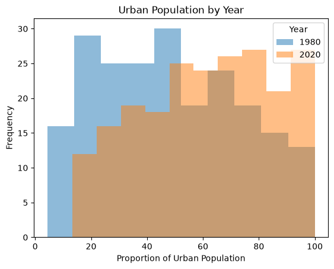

```python
# Write your own code

import pandas as pd
import matplotlib.pyplot as plt

# Read the dataset
wdi_urban = pd.read_csv("data_raw/wdi_urban.csv")
print(wdi_urban.head())

# Create a list of unique years
list_years = pd.unique(wdi_urban["year"])
print(list_years)

# Create a histogram for each year
for year in list_years:
    df = wdi_urban.query("year == @year")
    plt.hist(x=df["prop_urbanpopulation"], alpha=0.5)


# Add labels, title, and legend
plt.xlabel("Proportion of Urban Population")
plt.ylabel("Frequency")
plt.title("Urban Population by Year")
plt.legend(labels=list_years, title="Year")

plt.show()
```

# Review of last lecture

(k) Composite operations on arrays

- Define $r = 0.04$
- Define two arrays $A$ and $T$ using "np.array()", assigning the following values

$ a = \begin{pmatrix} a_0 \\ a_1 \\ a_2 \end{pmatrix} = \begin{pmatrix} 20 \\ 30 \\ 15 \end{pmatrix}, \qquad t = \begin{pmatrix} t_0 \\ t_1 \\ t_2 \end{pmatrix} = \begin{pmatrix} 0 \\ 1 \\ 2 \end{pmatrix} $

- Use element-by-element vector operations to compute a new array $M$ of length 3:

$ M = \begin{pmatrix} a_1 / (1+r)^{t_0} \\ a_2 / (1+r)^{t_1} \\ a_3 / (1+r)^{t_2} \end{pmatrix} $

- Compute the sum of the values of $M$ using "M.sum()"

Note: I am using subscripts to denote the individual elements of $a$ and $t$.

- In the code just enter the values of $a$ and $t$.
- To get full points you must do all of the above tasks

```python
# Write your own code


import numpy as np

# Define r
r = 0.04

# Define arrays
a = np.array([20, 30, 15])
t = np.array([0, 1, 2])

# Compute M
M = a / (1 + r)**t

# Display M
print(M)

# Compute the sum
print(M.sum())
```

```
[20.         28.84615385 13.8683432 ]
62.71449704142012
```